# Problem_Set_3

Salil Shahane

13/07/2019

# Section 1

```r
thefts_data <- tibble()
for(i in 2016:2019){
  theft_data_url <-
  paste("https://data.cityofchicago.org/resource/ijzp-q8t2.json?primary_type=THEFT&$limit=20000&year=",i, collapse=" ")
  data <-read_json(theft_data_url,simplifyVector = TRUE)
  data[22]<- NULL
  thefts_data <- bind_rows(thefts_data,data)
}

#1.2
thefts_data<- thefts_data%>%
  mutate(dates=ymd_hms(date))%>%
  mutate(years=year(dates))%>%
  mutate(day=day(dates))%>%
  mutate(week=week(dates))%>%
  mutate(hour=hour(dates))%>%
  mutate(month=month(dates))


#thefts_data$month <- NULL
thefts_data<- thefts_data%>%
  drop_na(latitude,longitude)

#1.3

thefts_data <- thefts_data%>%
  mutate(
  category= if_else(thefts_data$description=="$500 AND UNDER"
 |thefts_data$description=="POCKET_PICKING"|
  thefts_data$description=="PURSE_SNATCHING","petty","grand")
 )
```

# Section 2

```r
#2.1

thefts_data <-
  st_as_sf(thefts_data, coords = c("longitude","latitude"), crs=4326, remove = FALSE)


#2.2

thefts_fil <- thefts_data%>%
  filter(month%in%c(month(now())-2,month(now())-1))
```

# Plot_Question 2

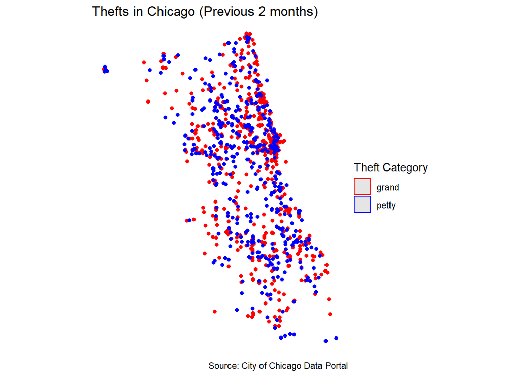

```r
library(ggplot2)

thefts_fil1 <- thefts_fil%>%sample_frac(0.1)
ggplot()+
  geom_sf(
    data=thefts_fil1,
    aes(color=category))+
  theme_void()+
  ggtitle("Thefts in Chicago (Previous 2 months)")+
  labs(
    caption= "Source: City of Chicago Data Portal"
  )+
  scale_color_manual(values = c("grand"="red","petty"="blue"), name= "Theft Category")
```

```r
#2.3

library(tidycensus)


census_data <- load_variables(2016, "acs5")


cook <- get_acs(
  geography = "tract",
  variables = "B01003_001",
  state = "IL",
  county = "Cook",
  geometry = TRUE
  )
cook <- st_transform(cook, 4326)

thefts_merged <- st_join(
  thefts_data,cook,
  join= st_within
)

#2.4

thefts_merged$geometry <- NULL

thefts_agg<- thefts_merged%>%
  group_by(NAME,GEOID)%>%
  mutate(count=n())%>%
  summarise(average_thefts= mean(count))

thefts_joined <-
  cook%>%
  left_join(thefts_agg, by="GEOID")%>%
  drop_na()%>%
  mutate(thefts_pc = (average_thefts/estimate))
```

# Plot_2

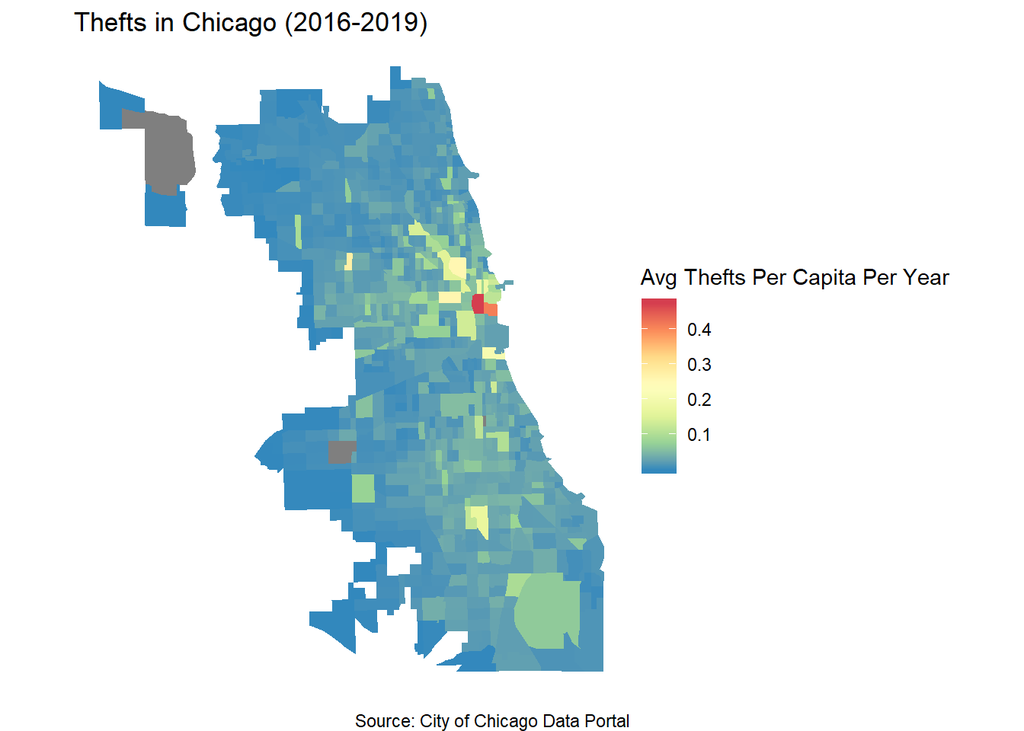

```r
library(sf)
ggplot()+
  geom_sf(
    data=thefts_joined,
    aes(fill= thefts_pc),color=NA
  )+
  theme_void()+
  ggtitle("Thefts in Chicago (2016-2019)")+
  labs(
    caption= "Source: City of Chicago Data Portal"
  )+
  scale_fill_distiller(
    palette= "Spectral",
    name= "Avg Thefts Per Capita Per Year",

  )
```

# Questions on the plot

•Why do you think thefts per capita is higher in the Loop and northwest side?

Ans: The thefts per capita is higher in the loop because the thefts (mostly petty thefts) are higher in that area as we can see from plot 1.

•What changes could we make to the map to further clarify the spatial distribution of thefts?

Ans: We could use facet_wrap to add additional maps which also show the median_income, racial distribution and poverty levels in different parts of the state. So that we can have a more conclusive map as to why thefts in particular areas is higher.

# Section 3

```r
library(tidycensus)
ccok_reg_data <- get_acs(
  geography = "tract",
  county="Cook",
  state = "IL",
  variables = c(total_population="B01003_001", white_pop = "B02001_002",
  med_income= "B06011_001", below_poverty_line="B17020_002",
  bachelor_degree_holders = "B06009_005", gender_male= "B01001_002"),
  geometry=  TRUE)

ccok_reg_data <- ccok_reg_data %>%
  select(-moe)%>%
  spread(variable, estimate)

ccok_reg_data <- ccok_reg_data%>%
  mutate(pct_white= white_pop/total_population)%>%
  mutate(pct_degree_holder = bachelor_degree_holders/total_population)%>%
  mutate(pct_below_poverty = below_poverty_line/total_population)%>%
  mutate(pct_male= gender_male/total_population)

ccok_reg_data<- st_transform(ccok_reg_data, 4326)

ccok_reg_data1 <-
  st_join(ccok_reg_data, thefts_joined, join= st_within)

#Stargazer

library(stargazer)
fit<- lm(thefts_pc ~ med_income + pct_white + pct_degree_holder + pct_below_poverty + pct_male, data= ccok_reg_data1)
stargazer(fit, type = "html")
```

|  | *Dependent variable:* |
| --- | --- |
|  | thefts_pc |
| med_income | 0.00000*** |
|  | (0.00000) |
| pct_white | -0.038*** |
|  | (0.005) |
| pct_degree_holder | 0.083*** |
|  | (0.019) |
| pct_below_poverty | 0.031** |
|  | (0.012) |
| pct_male | 0.041 |
|  | (0.026) |
| Constant | -0.006 |
|  | (0.013) |
| Observations | 834 |
| R<sup>2</sup> | 0.122 |
| Adjusted R<sup>2</sup> | 0.117 |
| Residual Std. Error | 0.032 (df = 828) |
| F Statistic | 22.974*** (df = 5; 828) |
| *Note:* | p<0.1; p<0.05; p<0.01 |

# Questions

3.1. Do you need to include weights in your regression? Fixed effects? Interaction terms? What should wedo with missing values? Does our regression specification make sense?

Ans: Yes we need to include weights in regression as all these factors (like median_income, education, race etc.) affect variedly the thefts per capita. We also need to include the fixed effects because federal laws concerning punitive/preventive actions against theft could change over a period. We also need to add interaction terms as the regressors (like median income and pct_degree holders) are to a certain extent dependent on each other. We can control for missing values by using a Difference in Differnce estimator.

3.2. Do you think the coefficients here are reasonable? Which one most influences the number of thefts?

Ans: The coefficients are not exactly reasonable as we have missing values. According to the regression model the most influential variable is pct_degree_holder.

3.3. Are there variables that you think should be included? Can this regression be interpreted as causal?

Ans: The regression model cannot be interpreted as causal as there are omitted variables and the sample size is less. We could include other variables like reported thefts, criminal history